# Capstone Project

Frank Cheon

October 25, 2017

## 0.1 Analysis of Home Mortgages in NY

# 1 Introduction

This dataset covers all mortgage loan decisions for New York, USA.

# 2 Sample Story

A client wishes to buy a home, but they do not have full cash-in-hand. So the client must apply for a mortgage loan. They proceed to tell the bank all their financial matters and the home that they wish to purchase. Once the bank makes its decision to approve the loan, the client will sign all necessary papers to close the deal. This is called **Loan Origination**.

# 3 Understanding the Data

The data can be grouped into 5 major categories:

- **Loan** - Lien status, any action taken on the loan, purpose for the loan and type of loan applied
- **Applicant** - The demographic for the applicant and any co-applicant is included, such as their gender, race and ethnicity.
- **Property Type** - Is the loan for a 1-4 family home, a multifamily home (apartment/condo building) and manufactured housing. This data also includes if the applicant will be living in the building.
- **Location** - The region/metro area informatics within state of New York. Where the building in question is located.
- **Lender** - Any federal agency or banking institution the applicant is working with.

# 4 Data Analysis

Let us dive into exploring the acquired dataset and see what we can understand.

```r
library(ggplot2)
library(dplyr)
library(tidyr)
library(readr)
library(caTools)
library(rpart)
library(rpart.plot)
library(ROCR)

rm(list=ls())

fillColor = "#FFA07A"
fillColor2 = "#666666"

mortgage <- read_csv("C:/Home mortgage.csv")
```

## 4.1 Loan application and action taken analysis

### 4.1.1 Action Taken by percentage

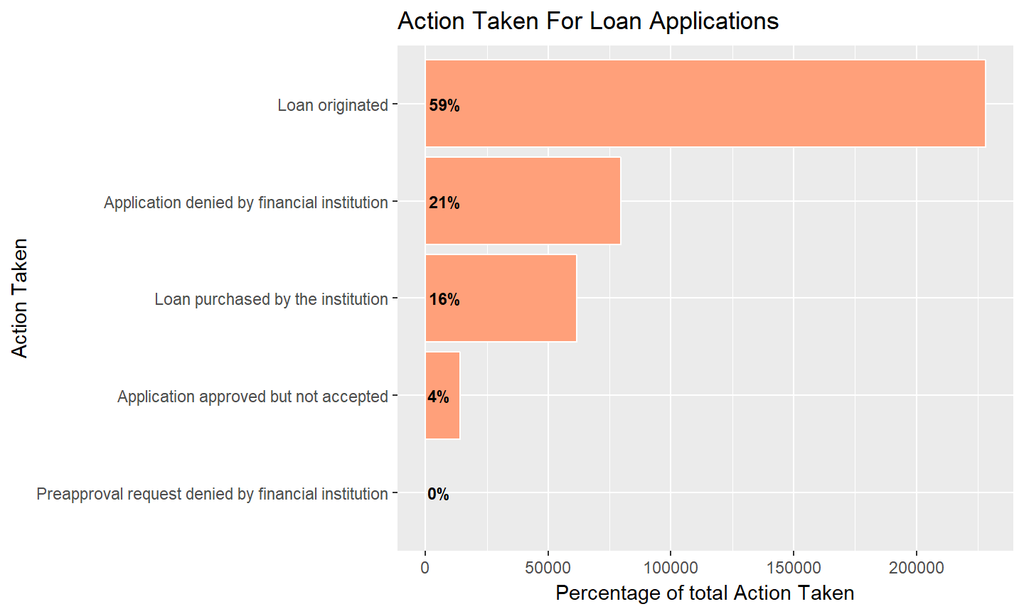

```r
mortgage_refine <- mortgage %>%
    subset(action_taken_name != "File closed for incompleteness") %>%
    subset(action_taken_name != "Application withdrawn by applicant")

MortgageActions <- mortgage_refine %>% group_by(action_taken_name) %>%
  summarise(SummaryActionTaken = n())%>%
  mutate(PercentageActionTaken = round(SummaryActionTaken/sum(SummaryActionTaken)*100))

ggplot(MortgageActions, aes(x=reorder(action_taken_name, SummaryActionTaken), y= SummaryActionTaken))+
  geom_bar(stat="identity", col="white", fill = fillColor) +
  geom_text(aes(x=action_taken_name, y=1,
                label = paste(PercentageActionTaken,"%", sep="")),
            hjust=-.1, vjust=.5, size=3, col="black", fontface = "bold") +
  labs(x= "Action Taken", y="Percentage of total Action Taken",
       title = "Action Taken For Loan Applications") +
  scale_y_continuous()+
  coord_flip()
```

The plot shows that approx. **~59%** of the loan applications were “Loan Originated”, which shows they were approved and closing the deal.

## 4.2 Gender comaprison

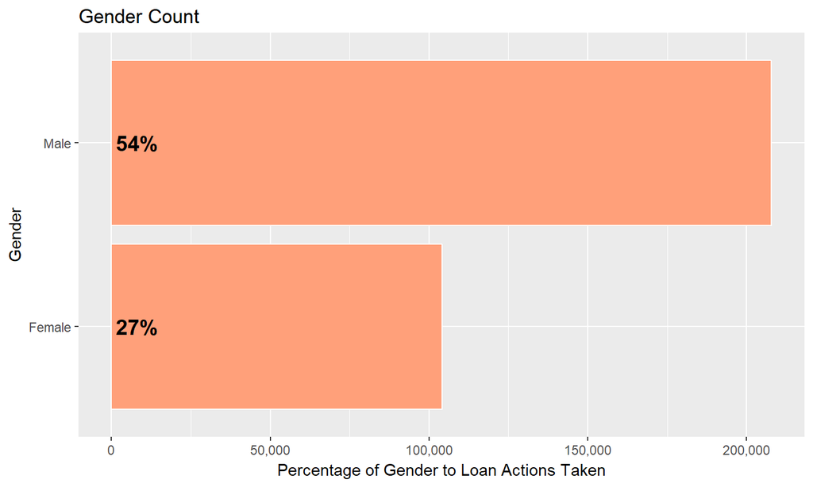

```r
MortgageGender <- mortgage_refine %>%
  group_by(applicant_sex_name) %>%
  summarise(SummaryGender = n()) %>%
  mutate(PercentGender= round(SummaryGender/sum(SummaryGender)*100)) %>%
  arrange(desc(SummaryGender)) %>%
  subset(applicant_sex_name != "Not applicable") %>%
  subset(applicant_sex_name != "Information not provided by applicant in mail, Internet, or telephone application")

ggplot(MortgageGender, aes(x= applicant_sex_name, y= SummaryGender)) +
  geom_bar(stat="identity", col="white", fill = fillColor) +
  geom_text(aes(x=applicant_sex_name, y=1,
                label = paste(PercentGender, "%", sep= "")),
            hjust = -.1, vjust = .5, size = 5, col="black", fontface = "bold")+
  labs(x= "Gender", y= "Percentage of Gender to Loan Actions Taken",
       title = "Gender Count") +
  scale_y_continuous(labels = scales :: comma)+
  coord_flip()
```

Within the gender data, we can find that male applies for loan in much higher rate than female.

## 4.3 Race dependencies on Action Taken

We explore the data to see how race plays a role in loan applicants.

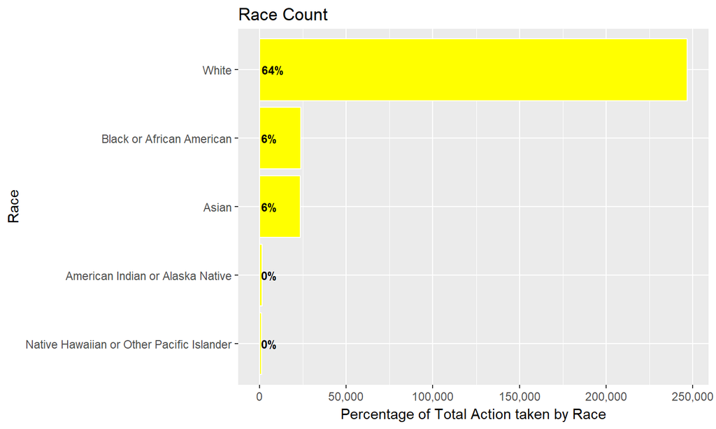

```r
MortgageRace <- mortgage_refine %>%
  group_by(applicant_race_name_1) %>%
  summarise(SummaryRace = n()) %>%
  mutate(PercentageRace = round(SummaryRace/sum(SummaryRace)*100)) %>%
  subset(applicant_race_name_1 != "Information not provided by applicant in mail, Internet, or telephone application") %>%
  subset(applicant_race_name_1 != "Not applicable")

ggplot(MortgageRace, aes(x= reorder(applicant_race_name_1, SummaryRace), y= SummaryRace)) +
  scale_y_continuous(labels = scales :: comma)+
  geom_bar(stat="identity", col="white", fill = "yellow")+
  geom_text(aes(x=applicant_race_name_1, y=1,
                label = paste(PercentageRace,"%", sep= "")),
            hjust = -.1, vjust = .5, size = 3, col="black", fontface = "bold")+
  labs(x= "Race", y = "Percentage of Total Action taken by Race", title = "Race Count") +
  coord_flip()
```

This plot clearly shows that the majority of the loan applicants are “White” in NY.

If we dive into how each Race compare to their loan status is, we get:

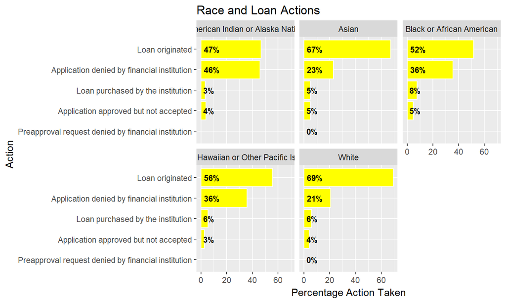

```r
MortgageRace1 <- mortgage_refine %>%
  group_by(applicant_race_name_1) %>%
  summarise(SummaryRace1 = n()) %>%
  subset(applicant_race_name_1 != "Information not provided by applicant in mail, Internet, or telephone application") %>%
  subset(applicant_race_name_1 != "Not applicable")

MortgageRaceAT <- mortgage_refine %>%
  group_by(action_taken_name, applicant_race_name_1) %>%
  summarise(SummaryRaceAT = n()) %>%
  subset(applicant_race_name_1 != "Information not provided by applicant in mail, Internet, or telephone application") %>%
  subset(applicant_race_name_1 != "Not applicable")

MortgageRace_Status <- merge(MortgageRaceAT, MortgageRace1) %>%
  mutate(percentage = (SummaryRaceAT/SummaryRace1)*100)

 ggplot(MortgageRace_Status, aes(x = reorder(action_taken_name, percentage),
                                    y = percentage)) +
  geom_bar(stat='identity',colour="white", fill ="yellow") +
  facet_wrap(~ applicant_race_name_1) +
  geom_text(aes(x = action_taken_name, y = 1, label = paste(round(percentage), "%", sep="")),
            hjust=-.1, vjust=.5, size = 3, colour = 'black',
            fontface = 'bold') +
  labs(x = 'Action', y = 'Percentage Action Taken', title = 'Race and Loan Actions') +
  coord_flip()
```

## 4.4 Income to Loan Origination

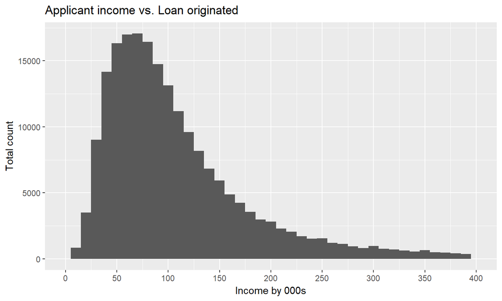

```r
actionoriginated = "Loan originated"

mortgage_refine %>%
  filter(action_taken_name == actionoriginated ) %>%
ggplot(aes(applicant_income_000s)) +
  scale_x_continuous(limits = c(0, 400),breaks=seq(0,400,50) ) +
  geom_histogram(binwidth = 10) +
  labs(x = 'Income by 000s', y = 'Total count', title = 'Applicant income vs. Loan originated')
```

Most income that has **Loan Originated** ranges around **$55K to $75K**.

## 4.5 Property

### 4.5.1 Loan Purpose Types

We will look in to the various types of loans applied

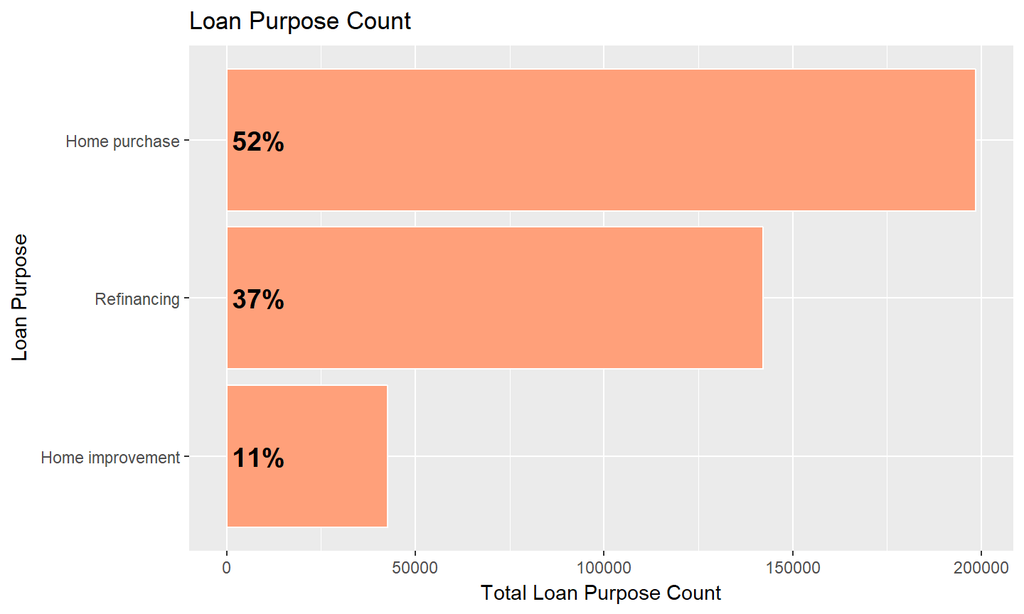

```r
MortgagePurpose <- mortgage_refine %>%
  group_by(loan_purpose_name) %>%
  summarise(SummaryPurpose = n()) %>%
  mutate(PercentPurpose = round(SummaryPurpose/sum(SummaryPurpose)*100)) %>%
  arrange(desc(SummaryPurpose))

ggplot(MortgagePurpose, aes(x= reorder(loan_purpose_name,SummaryPurpose), y= SummaryPurpose)) +
  geom_bar(stat="identity", col="white", fill = fillColor) +
  geom_text(aes(x=loan_purpose_name, y=1,
                label = paste(PercentPurpose,"%", sep= "")),
            hjust = -.1, vjust = .5, size = 5, col="black", fontface = "bold")+
  labs(x= "Loan Purpose", y= "Total Loan Purpose Count",
       title = "Loan Purpose Count") +
  coord_flip()
```

Loan Applicants apply for loan in 3 types, (in descending count)

**Home Purchase** - 52% **Refinancint** - 37% **Home Improvement** - 11%

### 4.5.2 Action Taken by County

We will take the top 10 most loan applied county, as this shows where the most sought-after county will be.

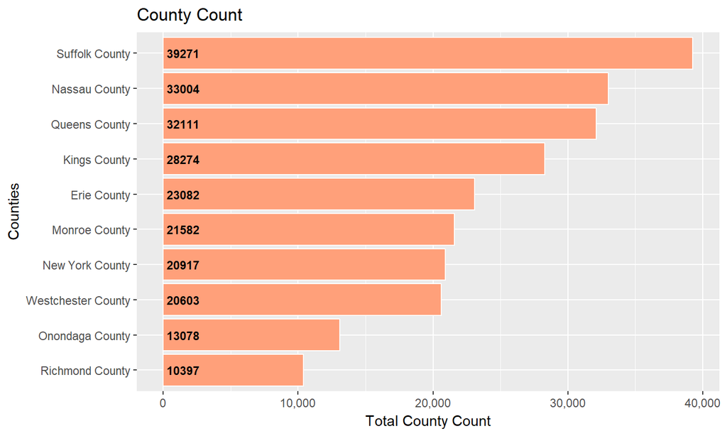

```r
MortgageCounty <- mortgage_refine %>%
  group_by(county_name) %>%
  summarise(SummaryCounty = n()) %>%
  mutate(PercentCounty = round(SummaryCounty/sum(SummaryCounty)*100))%>%
  arrange(desc(SummaryCounty)) %>%
    head(10)

ggplot(MortgageCounty, aes(x= reorder(county_name,SummaryCounty), y= SummaryCounty)) +
  geom_bar(stat="identity", col="white", fill = fillColor) +
  geom_text(aes(x=county_name, y=1,
                label = paste(SummaryCounty, sep= "")),
            hjust = -.1, vjust = .5, size = 3, col="black", fontface = "bold")+
  labs(x= "Counties", y= "Total County Count",
       title = "County Count") +
  scale_y_continuous(labels = scales :: comma)+
  coord_flip()
```

We can see that 7 out of 10 top 10 counties all fall near New York City which does make sense as it is the most highly populated region in state NY.

### 4.5.3 Property Types

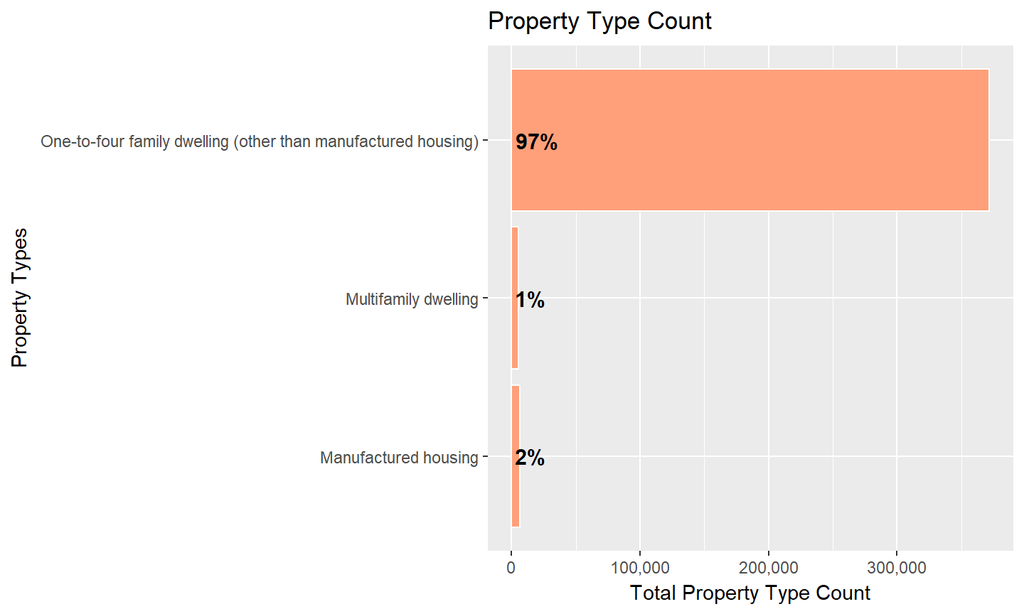

```r
MortgagePropertyType <- mortgage_refine %>%
  group_by(property_type_name) %>%
  summarise(SummaryPropertyType = n()) %>%
  mutate(PercentPropertyType = round(SummaryPropertyType/sum(SummaryPropertyType)*100)) %>%
  arrange(desc(SummaryPropertyType))

ggplot(MortgagePropertyType, aes(x= property_type_name, y= SummaryPropertyType)) +
  geom_bar(stat="identity", col="white", fill = fillColor) +
  geom_text(aes(x=property_type_name, y=1,
                label = paste(PercentPropertyType, "%", sep= "")),
            hjust = -.1, vjust = .5, size = 4, col="black", fontface = "bold")+
  labs(x= "Property Types", y= "Total Property Type Count",
       title = "Property Type Count") +
  scale_y_continuous(labels = scales :: comma)+
  coord_flip()
```

The Previous county analysis showed that the highest applied counties mostly fall within the New York city, so this **property type** analysis actually is a curveball. Within such densely populated area per square mile, we expect to see Mutifamily dwelling to be in a much higher percentage. As the data shows, **97%** of applicants are applying for a one-to-four family dwelling.

# 5 Predictive Modeling

We will predict what the top qualities it takes to reach **Loan Originated** status.

```r
cartCols = c("action_taken","applicant_ethnicity",
                 "applicant_income_000s","applicant_race_1","co_applicant_ethnicity",
                 "co_applicant_sex", "county_code","hoepa_status","lien_status",
                 "loan_purpose","loan_type","msamd",
                 "owner_occupancy","preapproval",
                 "property_type","purchaser_type","loan_amount_000s")


mortgage_cart <- mortgage_refine %>% select(cartCols) %>%
  mutate(isLoanOriginated = FALSE)  %>%
  mutate(isLoanOriginated = replace(isLoanOriginated, action_taken == 1, TRUE)) %>%
  select(-action_taken)
mortgage_cart <- na.omit(mortgage_cart)
mortgage_cart$applicant_ethnicity = as.factor(mortgage_cart$applicant_ethnicity)
mortgage_cart$applicant_race_1 = as.factor(mortgage_cart$applicant_race_1)
mortgage_cart$co_applicant_ethnicity = as.factor(mortgage_cart$co_applicant_ethnicity)
mortgage_cart$co_applicant_sex = as.factor(mortgage_cart$co_applicant_sex)
mortgage_cart$hoepa_status =  as.factor(mortgage_cart$hoepa_status)
mortgage_cart$lien_status =  as.factor(mortgage_cart$lien_status)
mortgage_cart$loan_purpose =  as.factor(mortgage_cart$loan_purpose)
mortgage_cart$loan_type =  as.factor(mortgage_cart$loan_type)
mortgage_cart$owner_occupancy =  as.factor(mortgage_cart$owner_occupancy)
mortgage_cart$preapproval =  as.factor(mortgage_cart$preapproval)
mortgage_cart$property_type =  as.factor(mortgage_cart$property_type)
mortgage_cart$purchaser_type =  as.factor(mortgage_cart$purchaser_type)
```

## 5.1 Logistic Regression Modeling

```
##    Min. 1st Qu.  Median    Mean 3rd Qu.    Max.
##  0.0000  0.3781  0.6787  0.6435  1.0000  1.0000
```

```
## [1] "Accuracy 0.837751549063887"
```

With the Logistic Regression Model, we see that the selected data has an accuracy of 84%. The top 10 most prioritized categorical variables are as follows:

```
##         loan_purpose3            loan_type2            loan_type3
##          0.000000e+00         3.414066e-232          1.380194e-63
##         loan_purpose2  applicant_ethnicity2      owner_occupancy2
##          3.187998e-47          1.251545e-46          4.078536e-46
## applicant_income_000s        property_type2          preapproval2
##          1.631672e-44          2.088795e-32          9.189725e-28
##           county_code
##          5.680410e-22
```

Let us proceed to the CART model.

## 5.2 CART Decision Tree Modeling

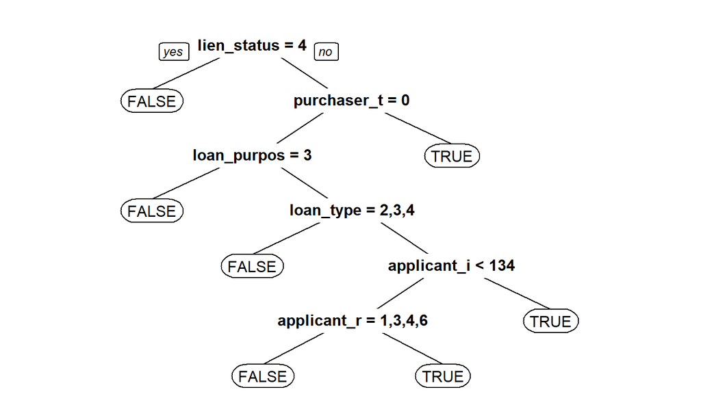

```r
set.seed(3000)
split = sample.split(mortgage_cart$isLoanOriginated, SplitRatio = 0.7)
Train = subset(mortgage_cart, split==TRUE, na.omit=T)
Test = subset(mortgage_cart, split==FALSE, na.omit = T)

# CART model
mortgagetree = rpart(isLoanOriginated ~ ., method="class", data = Train, control=rpart.control(minbucket=6))

prp(mortgagetree)
```

With the Decision Tree, the most important categories for **Loan Origination** is visible. From the top and descending in importance; Lien Status, Purchaser Type, Loan Purpose, Loan Type, Applicant Income, then Applicant Race.

We can see that when we cross check the 2 models, the priority list is very different from one another.

## 5.3 ROC and AUC model

We will check our accuracy based on ROC Curve Model.

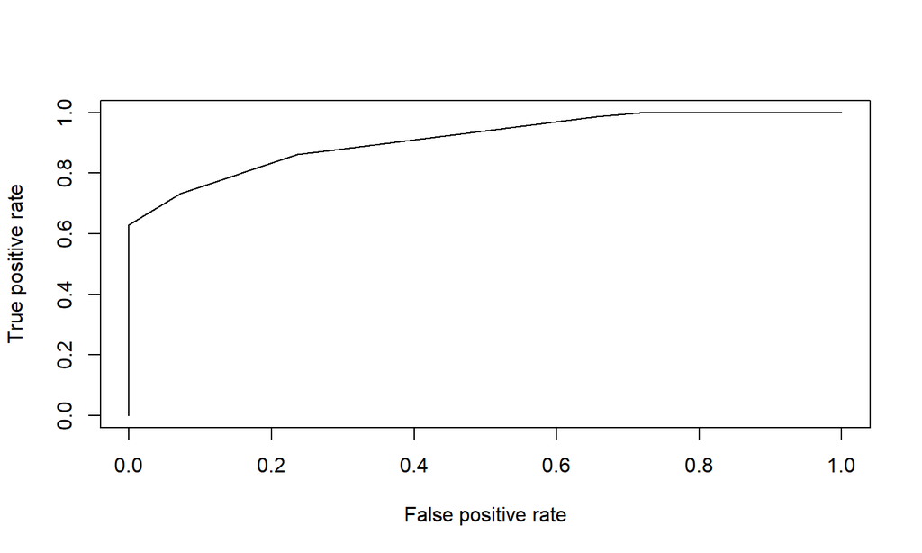

```r
#CART prediction

PredictCART = predict(mortgagetree, newdata = Test, type = "class")

# ROCR Prediction
PredictROC = predict(mortgagetree, newdata = Test)
pred = prediction(PredictROC[,2], Test$isLoanOriginated)
perf = performance(pred, "tpr", "fpr")
plot(perf)
```

Using the same ROC curve, we find our AUC accuracy rate.

```r
auc = performance(pred, measure='auc')
auc = auc@y.values[[1]]

auc
```

```
## [1] 0.9117559
```

# 6 FINAL THOUGHT

I believe the difference was because of the nature of logistic regression puts a limitation on the prediction, compared to the decision tree model.

My thinking process is that the logistic regression still is bound somewhat to a single dimensional prediction model, taking one dependent variable and pitting it against each independent variable to find value, then put together.

Decision tree feels more larger scale in the prediction, created to think about the final product, more than each step. The dependent variable is pitted against all independent variables at once, to create a higher accurate list of priorities.